# Stock Exchange Data Analysis

Vladyslav Karamushka

2026-04-27

## Dataset Overview

The analysis is based on daily trading data sourced from Yahoo Finance, specifically targeting companies within the S&P 500 (US) and STOXX Europe 600 (EU) indices, which was created by sampling tickers and taking data only for those companies to get symmetrical sector coverage. The dataset consists of **54,015 daily observations** across 15 variables, split relatively evenly between the US (27,709 observations) and the EU (26,306 observations). It comprises **121 matched companies** across the US and EU with symmetrical sector coverage. Minor differences in observation counts per company (capped at a maximum variance of 20 days) are statistically insignificant and will not affect the analysis results. All qualitative variables have been encoded as factors to facilitate structured, level-based statistical modeling.

## Distributional Assumptions & Statistical Testing

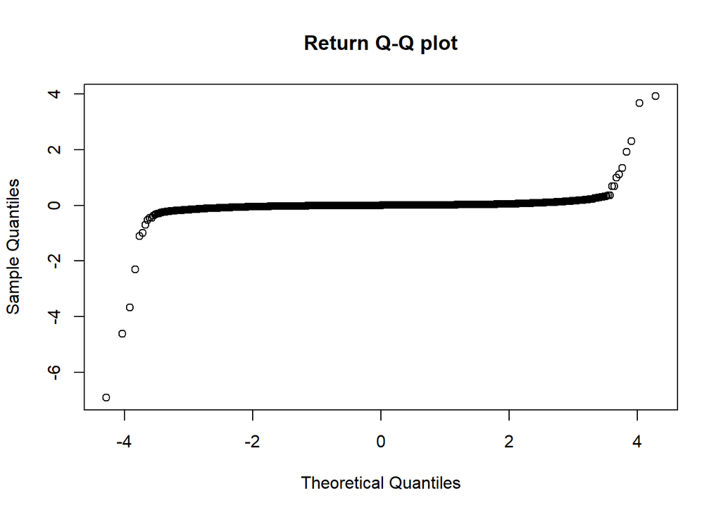

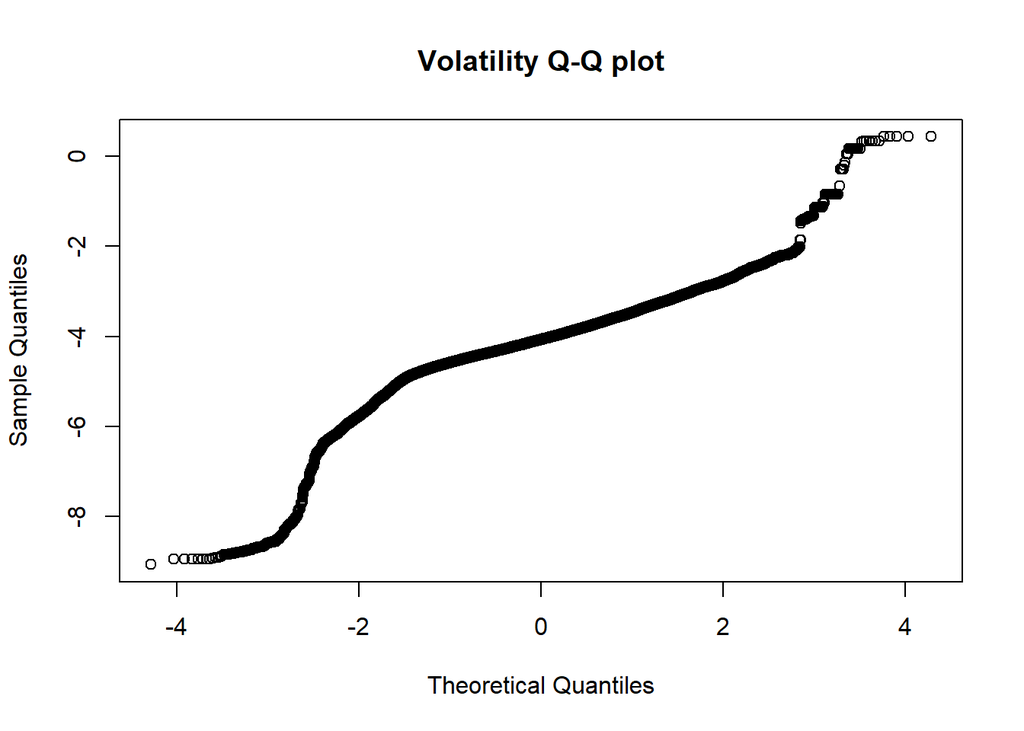

```
##
##  Lilliefors (Kolmogorov-Smirnov) normality test
##
## data:  long_dataset$volatility[1:nrow(long_dataset) * 20]
## D = 0.23145, p-value < 2.2e-16
```

Initial hypotheses assuming a normal distribution for key financial metrics (Returns and Volatility) were evaluated and subsequently rejected. Quantitative assessments, including Kolmogorov-Smirnov tests and Q-Q plot visualizations, confirm a definitive lack of normality across the dataset.

Crucially, the return data exhibits “fat tails” property. This structural characteristic indicates that extreme market movements (both positive and negative) occur with a significantly higher probability than a standard normal distribution would predict. Due to this non-normality, non-parametric statistical methods were prioritized for subsequent comparative analysis.

## Sectoral Return Analysis & Outlier Impact

To evaluate the “typical” baseline performance across sectors, preliminary visualizations (violin and box plots) were constructed using a filtered dataset. Values being further from 0 than for 0.03 were cut to preserve plot readability because of extreme values existence.

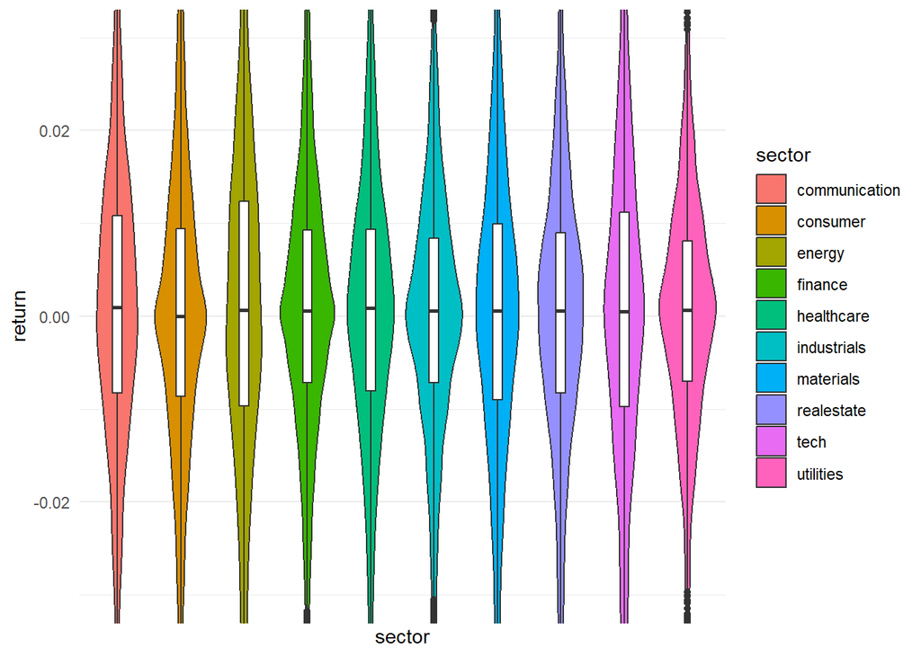

- **Baseline Performance:** The filtered data indicates that the Communication sector has the highest average returns, along with substantial instability. Healthcare presents an optimal risk-reward profile, offering profitability comparable to Energy and Tech, but with higher stability. Utilities represent the most stable sector overall, while Consumer Goods and Finance represent the least profitable segments.
- **The Impact of Tail Events:** Reintegrating the excluded outliers (approximately 8% of observations) significantly alters the sectoral profile, highlighting the danger of relying solely on filtered data. When accounting for extreme trading days, the mean returns for Healthcare and Energy outpace the rest of the market by a factor of 1.5.
- **Risk Symmetry:** Significant divergences between mean and median returns -— particularly in the Communication and Energy sectors —- underscore high vulnerability to asymmetric risk. For example, while Energy frequently captures outsized positive returns, Communication is uniquely vulnerable to rare but severe drawdowns.

## Regional Volatility Dynamics

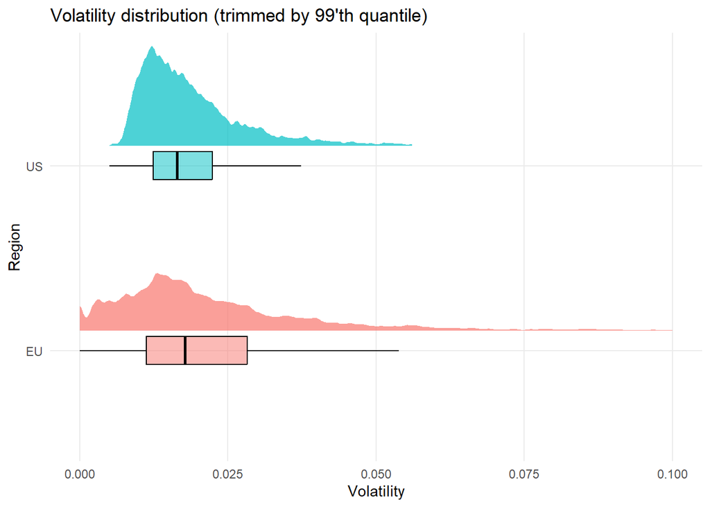

Regional volatility profiles were analyzed utilizing raincloud plots to map data density and distribution shape. Because of high number of observations and density of points under the plot, the “rain” was not been added. While baseline median volatility appears visually comparable between the two groups, advanced statistical testing reveals fundamental divergences.

Given the non-normal distribution of the volatility data (and its logarithmic transformations), a Mann-Whitney U test was applied to compare regional medians.

```
##
##  Wilcoxon rank sum test with continuity correction
##
## data:  volatility by region
## W = 963152, p-value = 0.009496
## alternative hypothesis: true location shift is not equal to 0
```

The resulting p-value confirms a statistically significant difference in baseline volatility between the regions. Overall, the EU market exhibits a structurally higher mean and variance, driven largely by a higher frequency of extreme volatility outliers compared to the US market.

```
## # A tibble: 2 × 5
##   region mean_ret median_ret sd_ret n_obs
##   <fct>     <dbl>      <dbl>  <dbl> <int>
## 1 EU       0.0248     0.0179 0.0468 26306
## 2 US       0.0192     0.0166 0.0102 27709
```

## Cross-Sectional Volatility Matrix

To present in a clear way the interaction between geography and industry, a median-based volatility heatmap was developed. Utilizing medians provides a clearer picture of structural volatility by ignoring the distortion caused by extreme tail events.

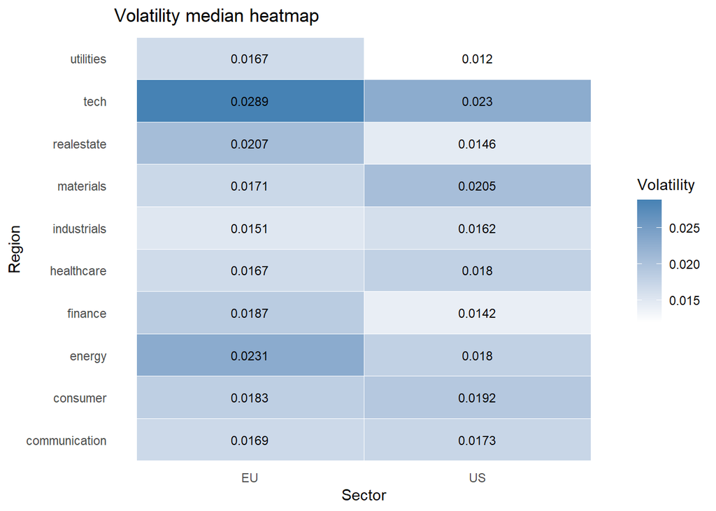

## Volatility-Volume Dynamics & Market Liquidity

The next phase of the analysis investigates the relationship between trading volume and price volatility. While both metrics share non-negative structural boundaries, initial hypotheses suggesting a strong positive correlation were largely unsupported by the data.

To effectively map this relationship and mitigate visual distortion from extreme tail events, the analytical domain was bounded (Volumes up to 10,000,000 shares; Volatility up to 0.10).

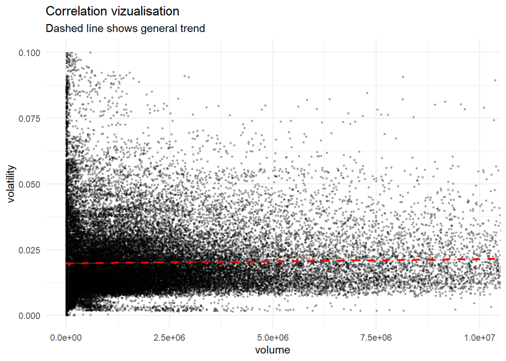

**Key Findings:**

- **Weak Linear Correlation:** The aggregate data demonstrates a structurally weak linear correlation between trading volume and volatility, approaching zero. Due to the high frequency of outliers, traditional linear regression models proved insufficient for capturing the true dynamics between these variables.
- **Pronounced Heteroscedasticity:** The most critical insight from this bivariate analysis is the presence of severe heteroscedasticity. Specifically, the variance (or spread) of volatility compresses significantly as trading volume increases.
- **Liquidity and Market Vulnerability:** This narrowing variance is a direct reflection of market liquidity mechanics. While the dataset naturally contains a higher concentration of lower-volume equities, a clear structural trend emerges:
- **Low-Volume Dynamics (Baseline Stability vs. Tail Risk):** For the majority of lower-volume equities, general market interest is subdued. Because their price movements have a marginally smaller impact on broader market capitalization, their day-to-day baseline volatility remains relatively low. However, this same lack of liquidity creates severe vulnerability to tail events, resulting in extreme, though infrequent, volatility spikes (outliers).
- **High-Volume Dynamics (Elevated Baseline vs. Shock Absorption):** Conversely, high-volume equities —- typically large firms —- experience a higher baseline level of volatility. This is driven by intense, continuous market interest, and the major impact these equities have on overall index valuations. Yet, while their day-to-day fluctuations are greater, it requires substantially more capital to distort their prices, lowering the risk of the extreme outlier events seen in thinly traded stocks.

```
##
##  Spearman's rank correlation rho
##
## data:  data_vol_cut$volatility and data_vol_cut$volume
## S = 2.0949e+13, p-value < 2.2e-16
## alternative hypothesis: true rho is not equal to 0
## sample estimates:
##       rho
## 0.1779118
```

Small, but statistically significant correlation existence confirms the result of the Spearman’s rank sum test.

## Predictive Modeling: Volatility Regression Analysis

Financial markets are inherently chaotic, the direct prediction of raw daily financial variables is highly complex and typically requiring advanced proprietary modeling. Therefore, the objective of this linear regression model is not pure forecasting, but rather quantifying the structural impact and statistical significance of various market factors on asset stability.

**Data Transformation:**

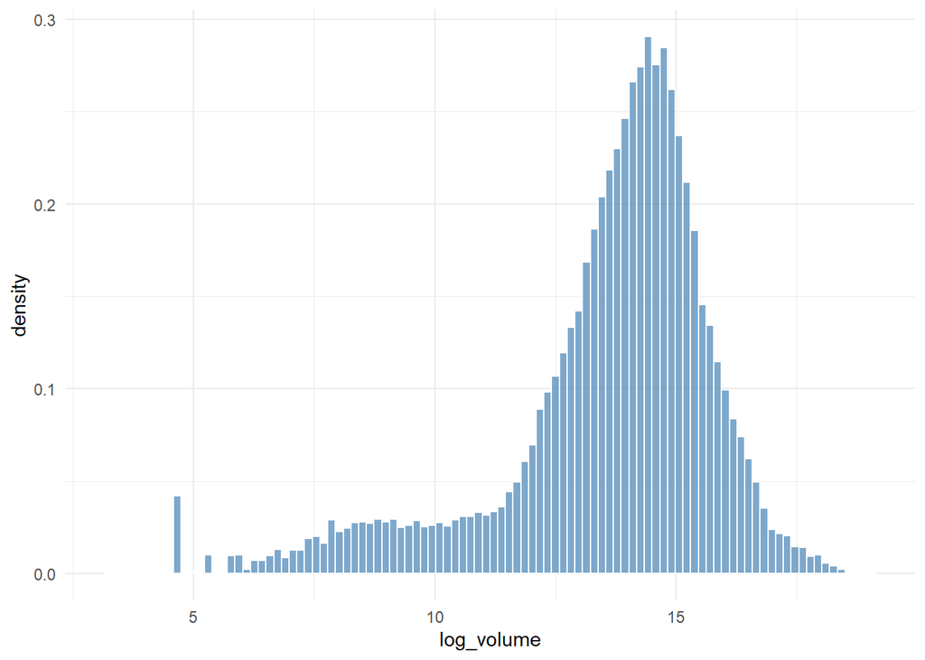

- **Logarithmic Scaling & Outlier Management:** To address severe right-skewness and normalize the distributions for linear modeling, logarithmic transformations were applied to both Volatility and Volume (Market Capitalization was previously transformed). Extreme outliers were systematically trimmed to prevent the distortion of regression coefficients.

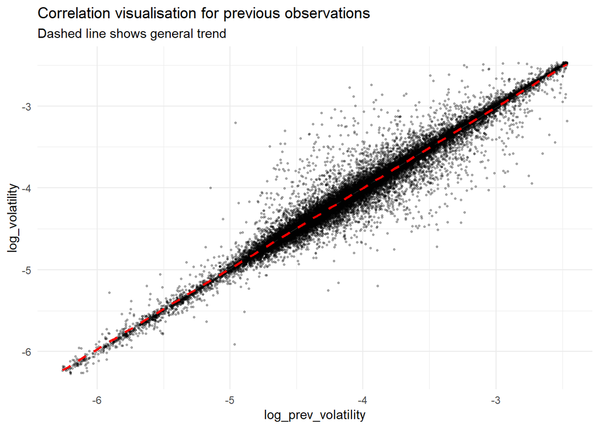

- **Mitigating Autocorrelation:** Financial volatility exhibits a strong “memory” effect (autocorrelation) and heteroscedasticity. Current volatility is deeply correlated with historical observations. To neutralize error autocorrelation and capture this dynamic, a lagged variable (log_prev_volatility, representing the previous day’s volatility) was introduced. Raw open/close prices and baseline returns were excluded from the predictor set due to their instability and mathematical redundancy with the target variable.

## Regression Results & Key Market Insights

```
##
## Call:
## lm(formula = log_volatility ~ log_prev_volatility + log_market_cap +
##     region + sector + log_volume, data = long_dataset_for_lm)
##
## Residuals:
##      Min       1Q   Median       3Q      Max
## -1.28486 -0.01961  0.00244  0.02198  1.76633
##
## Coefficients:
##                       Estimate Std. Error  t value Pr(>|t|)
## (Intercept)         -0.0750078  0.0071429  -10.501  < 2e-16 ***
## log_prev_volatility  0.9788701  0.0008646 1132.220  < 2e-16 ***
## log_market_cap      -0.0062892  0.0003346  -18.798  < 2e-16 ***
## regionUS            -0.0028950  0.0010682   -2.710  0.00673 **
## sectorconsumer       0.0027162  0.0029856    0.910  0.36295
## sectorenergy         0.0023604  0.0034630    0.682  0.49549
## sectorfinance        0.0027945  0.0029810    0.937  0.34854
## sectorhealthcare     0.0065409  0.0031475    2.078  0.03770 *
## sectorindustrials    0.0044212  0.0030074    1.470  0.14154
## sectormaterials      0.0062299  0.0033975    1.834  0.06671 .
## sectorrealestate    -0.0038177  0.0033254   -1.148  0.25097
## sectortech           0.0093750  0.0033439    2.804  0.00505 **
## sectorutilities      0.0009732  0.0034731    0.280  0.77931
## log_volume           0.0096780  0.0003821   25.331  < 2e-16 ***
## ---
## Signif. codes:  0 '***' 0.001 '**' 0.01 '*' 0.05 '.' 0.1 ' ' 1
##
## Residual standard error: 0.09484 on 47211 degrees of freedom
## Multiple R-squared:  0.9694, Adjusted R-squared:  0.9694
## F-statistic: 1.149e+05 on 13 and 47211 DF,  p-value: < 2.2e-16
```

The linear regression model has an exceptionally high Adjusted R-squared value approaching 1.0. While absolute predictive perfection is atypical in financial modeling, this result validates several critical market mechanics: